# Numpy Reminders:

## Pandas Viz Reminders

```python
#Display plots directly in jupyter
%matplotlib inline
```

```python
#Import data
df1 = pd.read_csv("./original/TSA_COURSE_NOTEBOOKS/03-Pandas-Visualization/df1.csv",index_col=0)
df2 = pd.read_csv('./original/TSA_COURSE_NOTEBOOKS/03-Pandas-Visualization/df2.csv')
```

### Plot Types

There are several plot types built into pandas; most of them are statistical by nature:

```
df.plot.hist()     histogram
df.plot.bar()      bar chart
df.plot.barh()     horizontal bar chart
df.plot.line()     line chart
df.plot.area()     area chart
df.plot.scatter()  scatter plot
df.plot.box()      box plot
df.plot.kde()      kde plot
df.plot.hexbin()   hexagonal bin plot
df.plot.pie()      pie chart
```

You can also call specific plots by passing their name as an argument, as with `df.plot(kind='area')`.

### Histograms

This is one of the most commonly used plots. Histograms describe the distribution of continuous data by dividing the data into "bins" of equal width, and plotting the number of values that fall into each bin. [[reference]](https://pandas.pydata.org/pandas-docs/stable/generated/pandas.DataFrame.plot.hist.html)

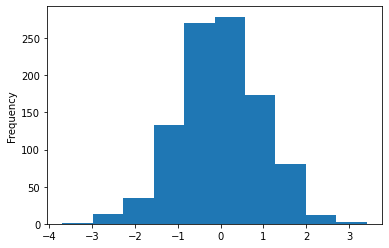

```python
df1['A'].plot.hist();
```

We can add settings to do things like bring the x- and y-axis values to the edge of the graph, and insert lines between vertical bins:

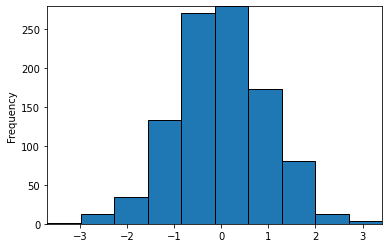

```python
df1['A'].plot.hist(edgecolor='k').autoscale(enable=True, axis='both', tight=True)
```

You can use any [matplotlib color spec](https://matplotlib.org/api/colors_api.html) for **edgecolor**, such as `'b', 'g', 'r', 'c', 'm', 'y', 'k', 'w'`, or the string representation of a float value for shades of grey, such as `'0.5'`

For **autoscale** the axis can be set to `'x'`, `'y'` or `'both'`

We can also change the number of bins (the range of values over which frequencies are calculated) from the default value of 10:

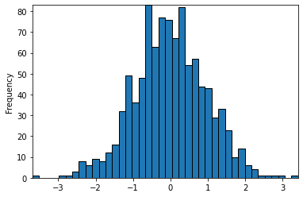

```python
df1['A'].plot.hist(bins=40, edgecolor='k').autoscale(enable=True, axis='both', tight=True)
```

You can also access an histogram like this:

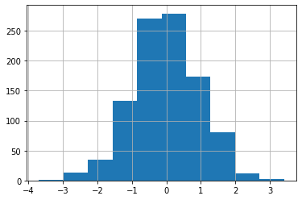

```python
df1['A'].hist();
```

For more on using `df.hist()` visit https://pandas.pydata.org/pandas-docs/stable/generated/pandas.DataFrame.hist.html

## Barplots

Barplots are similar to histograms, except that they deal with discrete data, and often reflect multiple variables. [[reference]](https://pandas.pydata.org/pandas-docs/stable/generated/pandas.DataFrame.plot.bar.html)

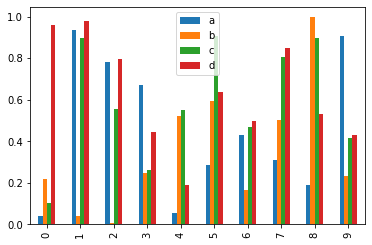

```python
df2.plot.bar();
```

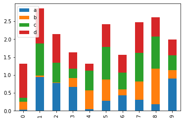

```python
df2.plot.bar(stacked=True);
```

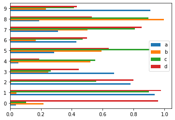

```python
# USE .barh() TO DISPLAY A HORIZONTAL BAR PLOT
df2.plot.barh();
```

## Line Plots

Line plots are used to compare two or more variables. By default the x-axis values are taken from the index. [[reference]](https://pandas.pydata.org/pandas-docs/stable/generated/pandas.DataFrame.plot.line.html)

Line plots happen to be the default pandas plot. They are accessible through `df.plot()` as well as `df.plot.line()`

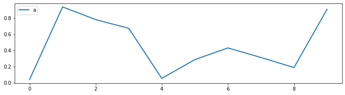

```python
df2.plot.line(y='a',figsize=(12,3),lw=2);
```

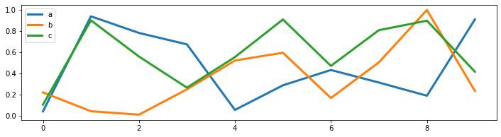

```python
# Use lw to change the size of the line

df2.plot.line(y=['a','b','c'],figsize=(12,3),lw=3);
```

## Area Plots

Area plots represent cumulatively stacked line plots where the space between lines is emphasized with colors. [[reference]](https://pandas.pydata.org/pandas-docs/stable/generated/pandas.DataFrame.plot.area.html)

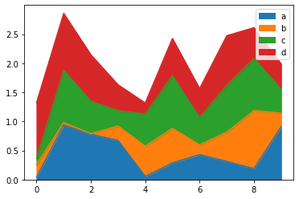

```python
df2.plot.area();
```

It often helps to mute the colors by passing an **alpha** transparency value between 0 and 1.

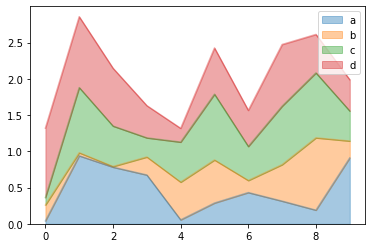

```python
df2.plot.area(alpha=0.4);
```

To produce a blended area plot, pass a **stacked=False** argument:

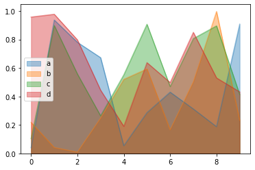

```python
df2.plot.area(stacked=False, alpha=0.4);
```

## Scatter Plots

Scatter plots are a useful tool to quickly compare two variables, and to look for possible trends. [[reference]](https://pandas.pydata.org/pandas-docs/stable/generated/pandas.DataFrame.plot.scatter.html)

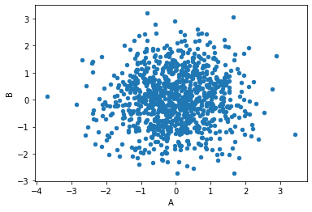

```python
df1.plot.scatter(x='A',y='B');
```

### Scatter plots with colormaps

You can use **c** to color each marker based off another column value. Use `cmap` to indicate which colormap to use.  
For all the available colormaps, check out: http://matplotlib.org/users/colormaps.html

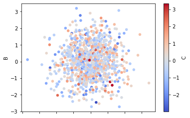

```python
df1.plot.scatter(x='A',y='B',c='C',cmap='coolwarm');
```

### Scatter plots with sized markers

Alternatively you can use **s** to indicate marker size based off another column. The **s** parameter needs to be an array, not just the name of a column:

```
/home/rangelrey/.local/share/virtualenvs/timeseriesanalysis-xa2U-udI/lib/python3.6/site-packages/matplotlib/collections.py:886: RuntimeWarning: invalid value encountered in sqrt
  scale = np.sqrt(self._sizes) * dpi / 72.0 * self._factor
```

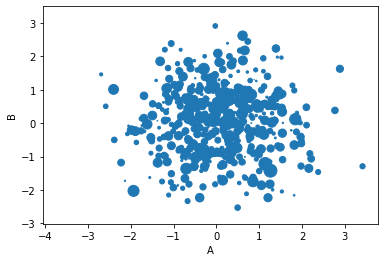

```python
df1.plot.scatter(x='A',y='B',s=df1['C']*50);
```

The warning above appeared because some `df1['C']` values are negative. We can fix this finding the minimum value, writing a function that adds to each value, and applying our function to the data with **.apply(func)**.

Also, these data points have a lot of overlap. We can address this issue by passing in an **alpha** blending value between 0 and 1 to make markers more transparent.

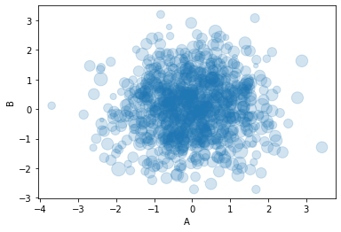

```python
def add_three(val):
    return val+3

df1.plot.scatter(x='A',y='B',s=df1['C'].apply(add_three)*45, alpha=0.2);
```

## BoxPlots

Box plots, aka "box and whisker diagrams", describe the distribution of data by dividing data into *quartiles* about the mean.  
Look [here](https://en.wikipedia.org/wiki/Box_plot) for a description of boxplots. [[reference]](https://pandas.pydata.org/pandas-docs/stable/visualization.html#box-plots)

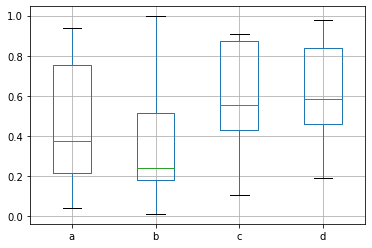

```python
df2.boxplot();
```

### Boxplots with Groupby

To draw boxplots based on groups, first pass in a list of columns you want plotted (including the groupby column), then pass **by='columname'** into `.boxplot()`. Here we'll group records by the **'e'** column, and draw boxplots for the **'b'** column.

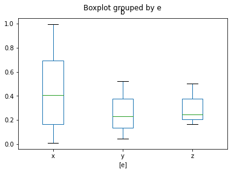

```python
df2[['b','e']].boxplot(by='e', grid=False);
```

In the next section on Customizing Plots we'll show how to change the title and axis labels.

## Kernel Density Estimation (KDE) Plot

In order to see the underlying distribution, which is similar to an histogram. These plots are accessible either through `df.plot.kde()` or `df.plot.density()` [[reference]](https://pandas.pydata.org/pandas-docs/stable/generated/pandas.DataFrame.plot.kde.html)

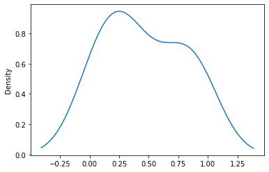

```python
df2['a'].plot.kde();
```

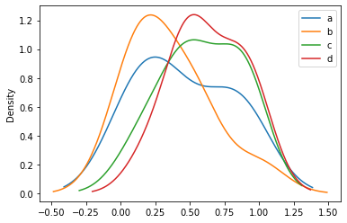

```python
df2.plot.density();
```

## Hexagonal Bin Plot

Useful for Bivariate Data, alternative to scatterplot. [[reference]](https://pandas.pydata.org/pandas-docs/stable/generated/pandas.DataFrame.plot.hexbin.html)

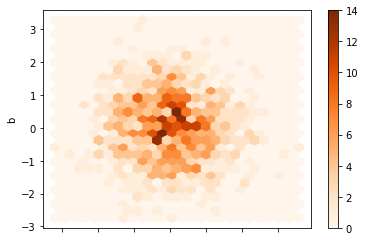

```python
# FIRST CREATE A DATAFRAME OF RANDOM VALUES
df = pd.DataFrame(np.random.randn(1000, 2), columns=['a', 'b'])

# MAKE A HEXAGONAL BIN PLOT
df.plot.hexbin(x='a',y='b',gridsize=25,cmap='Oranges');
```

# Customizing Pandas Plots

In this section we'll show how to control the position and appearance of axis labels and legends.  
For more info on the following topics visit https://pandas.pydata.org/pandas-docs/stable/generated/pandas.DataFrame.plot.html

## Colors, Widths and Linestyles

The pandas `.plot()` method takes optional arguments that allow you to control linestyles, colors, widths and more.

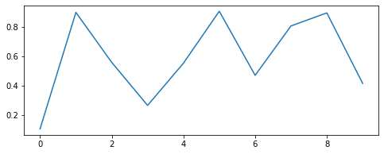

```python
# START WITH A SIMPLE LINE PLOT
df2['c'].plot(figsize=(8,3));
```

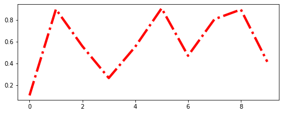

```python
df2['c'].plot.line(ls='-.', c='r', lw='4', figsize=(8,3));
```

For more on linestyles, click [here](https://matplotlib.org/api/_as_gen/matplotlib.lines.Line2D.html#matplotlib.lines.Line2D.set_linestyle).

## Adding Titles and Axis Labels

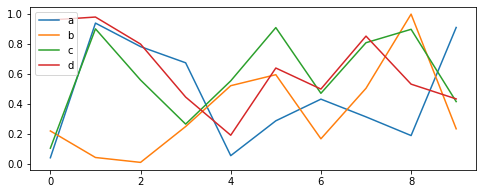

```python
# START WITH A SIMPLE MULTILINE PLOT
df2.plot(figsize=(8,3));
```

### Object-oriented plotting

When we call `df.plot()`, pandas returns a `matplotlib.axes.AxesSubplot` object. We can set labels on that object so long as we do it in the same jupyter cell. Setting an autoscale is done the same way.

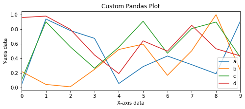

```python
title='Custom Pandas Plot'
ylabel='Y-axis data'
xlabel='X-axis data'

ax = df2.plot(figsize=(8,3),title=title)
ax.set(xlabel=xlabel, ylabel=ylabel)
ax.autoscale(axis='x',tight=True);
```

## Plot Legend Placement

Pandas tries to optimize placement of the legend to reduce overlap on the plot itself. However, we can control the placement ourselves, and even place the legend outside of the plot. We do this through the `.legend()` method. [[reference]](https://matplotlib.org/api/_as_gen/matplotlib.pyplot.legend.html)

For starters we can pass a location code. `.legend(loc=1)` places the legend in the upper-right corner of the plot.  
Alternatively we can pass a location string: `.legend(loc='upper right')` does the same thing.

| LOCATION CODE | LOCATION STRING |
| --- | --- |
| 0 | 'best' |
| 1 | 'upper right' |
| 2 | 'upper left' |
| 3 | 'lower left' |
| 4 | 'lower right' |
| 5 | 'right' |
| 6 | 'center left' |
| 7 | 'center right' |
| 8 | 'lower center' |
| 9 | 'upper center' |
| 10 | 'center' |

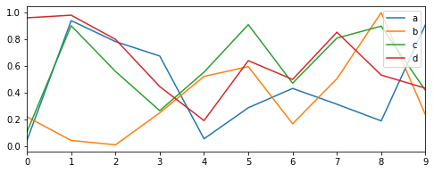

```python
ax = df2.plot(figsize=(8,3))
ax.autoscale(axis='x',tight=True)
ax.legend(loc=1);
```

We can pass a second argument, `bbox_to_anchor` that treats the value passed in through `loc` as an anchor point, and positions the legend along the x and y axes based on a two-value tuple.

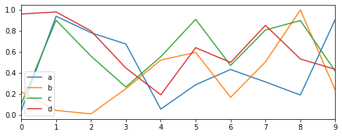

```python
# FIRST, PLACE THE LEGEND IN THE LOWER-LEFT
ax = df2.plot(figsize=(8,3))
ax.autoscale(axis='x',tight=True)
ax.legend(loc=3);
```

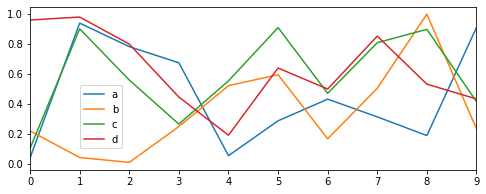

```python
# NEXT, MOVE THE LEGEND A LITTLE TO THE RIGHT AND UP
ax = df2.plot(figsize=(8,3))
ax.autoscale(axis='x',tight=True)
ax.legend(loc=3, bbox_to_anchor=(0.1,0.1));
```

### Placing the Legend Outside the Plot

In the above plot we passed `(0.1,0.1)` as our two-item tuple. This places the legend slightly to the right and slightly upward.  
To place the legend outside the plot on the right-hand side, pass a value greater than or equal to 1 as the first item in the tuple.

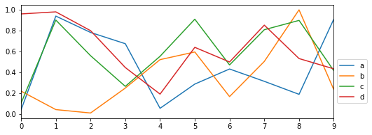

```python
ax = df2.plot(figsize=(8,3))
ax.autoscale(axis='x',tight=True)
ax.legend(loc=3, bbox_to_anchor=(1.0,0.1));
```

## Pandas Datetime Index

We'll usually deal with time series as a datetime index when working with pandas dataframes. Fortunately pandas has a lot of functions and methods to work with time series!  
For more on the pandas DatetimeIndex visit https://pandas.pydata.org/pandas-docs/stable/timeseries.html

Ways to build a DatetimeIndex:

```python
# THE WEEK OF JULY 8TH, 2018
idx = pd.date_range('7/8/2018', periods=7, freq='D')
idx
```

```
DatetimeIndex(['2018-07-08', '2018-07-09', '2018-07-10', '2018-07-11',
               '2018-07-12', '2018-07-13', '2018-07-14'],
              dtype='datetime64[ns]', freq='D')
```

```python
idx = pd.to_datetime(['Jan 01, 2018','1/2/18','03-Jan-2018',None])
idx
```

```
DatetimeIndex(['2018-01-01', '2018-01-02', '2018-01-03', 'NaT'], dtype='datetime64[ns]', freq=None)
```

```python
# Create a NumPy datetime array
some_dates = np.array(['2016-03-15', '2017-05-24', '2018-08-09'], dtype='datetime64[D]')
some_dates
```

```
array(['2016-03-15', '2017-05-24', '2018-08-09'], dtype='datetime64[D]')
```

```python
pd.to_datetime(['2/1/2018','3/1/2018'],format='%d/%m/%Y')
```

```
DatetimeIndex(['2018-01-02', '2018-01-03'], dtype='datetime64[ns]', freq=None)
```

# Time Resampling

```
df = pd.read_csv('../Data/starbucks.csv')
df['Date'] = pd.to_datetime(df['Date'])
df.set_index('Date',inplace=True)
```

## resample()

A common operation with time series data is resampling based on the time series index. Let's see how to use the resample() method. [[reference](https://pandas.pydata.org/pandas-docs/stable/generated/pandas.DataFrame.resample.html)]

```python
# Index_col indicates that the index will be the column called 'Date'
# parse_dates, transforms the strings into datetime format

df = pd.read_csv('./original/TSA_COURSE_NOTEBOOKS/Data/starbucks.csv', index_col='Date', parse_dates=True)
```

```python
# Our index
df.index
```

```
DatetimeIndex(['2015-01-02', '2015-01-05', '2015-01-06', '2015-01-07',
               '2015-01-08', '2015-01-09', '2015-01-12', '2015-01-13',
               '2015-01-14', '2015-01-15',
               ...
               '2018-12-17', '2018-12-18', '2018-12-19', '2018-12-20',
               '2018-12-21', '2018-12-24', '2018-12-26', '2018-12-27',
               '2018-12-28', '2018-12-31'],
              dtype='datetime64[ns]', name='Date', length=1006, freq=None)
```

When calling `.resample()` you first need to pass in a **rule** parameter, then you need to call some sort of aggregation function.

The **rule** parameter describes the frequency with which to apply the aggregation function (daily, monthly, yearly, etc.)  
It is passed in using an "offset alias" - refer to the table below. [[reference](http://pandas.pydata.org/pandas-docs/stable/user_guide/timeseries.html#offset-aliases)]

The aggregation function is needed because, due to resampling, we need some sort of mathematical rule to join the rows (mean, sum, count, etc.)

**TIME SERIES OFFSET ALIASES**

| ALIAS | DESCRIPTION |
| --- | --- |
| B | business day frequency |
| C | custom business day frequency (experimental) |
| D | calendar day frequency |
| W | weekly frequency |
| M | month end frequency |
| SM | semi-month end frequency (15th and end of month) |
| BM | business month end frequency |
| CBM | custom business month end frequency |
| MS | month start frequency |
| SMS | semi-month start frequency (1st and 15th) |
| BMS | business month start frequency |
| CBMS | custom business month start frequency |
| Q | quarter end frequency |
|  | intentionally left blank |

| ALIAS | DESCRIPTION |
| --- | --- |
| BQ | business quarter endfrequency |
| QS | quarter start frequency |
| BQS | business quarter start frequency |
| A | year end frequency |
| BA | business year end frequency |
| AS | year start frequency |
| BAS | business year start frequency |
| BH | business hour frequency |
| H | hourly frequency |
| T, min | minutely frequency |
| S | secondly frequency |
| L, ms | milliseconds |
| U, us | microseconds |
| N | nanoseconds |

Let's resample our dataframe, by using rule "A", which is year and frecuency and aggregate it with the mean

```python
# Yearly Means
df.resample(rule='A').mean()
```

| Date | Close | Volume |
| --- | --- | --- |
| 2015-12-31 | 50.078100 | 8.649190e+06 |
| 2016-12-31 | 53.891732 | 9.300633e+06 |
| 2017-12-31 | 55.457310 | 9.296078e+06 |
| 2018-12-31 | 56.870005 | 1.122883e+07 |

Resampling rule 'A' takes all of the data points in a given year, applies the aggregation function (in this case we calculate the mean), and reports the result as the last day of that year.

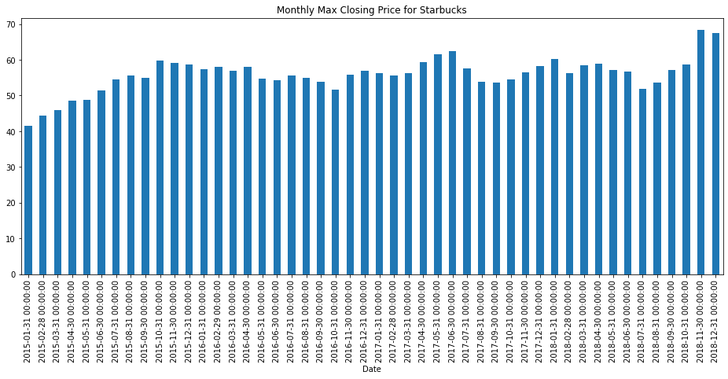

```python
title = 'Monthly Max Closing Price for Starbucks'
df['Close'].resample('M').max().plot.bar(figsize=(16,6), title=title,color='#1f77b4');
```